# Relatório Análise de Dados de Viagens

2023-12-07

## Instalando as bibliotecas

```r
options(repos = c(CRAN = "https://cran.rstudio.com/"))
install.packages('dplyr')
```

```r
install.packages('ggplot2')
library(dplyr)
library(ggplot2)
```

## Importando os dados

```r
dados <- read.csv(
  file = "C:/Users/Matheus/Desktop/MATHEUS/DATA/2019_Viagem.csv",
  sep = ';',
  dec = ',',
  fileEncoding = "latin1"
)
dim(dados)
```

```
## [1] 756704     16
```

O dataframe possui 756.704 linhas e 16 colunas.

## Visualização dos dados

```r
head(dados,10)
```

|  | Identificador.do.processo.de.viagem | Situação | Código.do.órgão.superior | Nome.do.órgão.superior | Código.órgão.solicitante | Nome.órgão.solicitante | CPF.viajante | Nome | Cargo | Período...Data.de.início | Período...Data.de.fim | Destinos | Motivo | Valor.diárias | Valor.passagens | Valor.outros.gastos |
| --- | --- | --- | --- | --- | --- | --- | --- | --- | --- | --- | --- | --- | --- | --- | --- | --- |
| 1 | 15045825 | Realizada | 26000 | Ministério da Educação | 26291 | Fundação Coordenação de Aperfeiçoamento de Pessoal de Nível Superior | ***.377.624-** | MARINA FERREIRA KITAZONO ANTUNES |  | 06/02/2019 | 07/02/2019 | Recife/PE | Regresso de bolsista CAPES do exterior- PE ( PROGRAMAS ESTRATÉGICOS -DRI ) | 0.00 | 3406.33 | 0 |
| 2 | 15100682 | Realizada | 26000 | Ministério da Educação | 26291 | Fundação Coordenação de Aperfeiçoamento de Pessoal de Nível Superior | ***.831.975-** | JORGE ANDRE DE CARVALHO MENDONCA |  | 01/02/2019 | 02/02/2019 | Recife/PE | Capacitação PDSE (Programa de Doutorado Sanduíche no Exterior). | 0.00 | 2925.83 | 0 |
| 3 | 15114708 | Realizada | 26000 | Ministério da Educação | 26291 | Fundação Coordenação de Aperfeiçoamento de Pessoal de Nível Superior | ***.325.718-** | MARCO ANTONIO COUTO JUNIOR | PESQUISADOR EM GEOCIENCIA | 01/02/2019 | 01/02/2019 | São Paulo/SP | Capacitação no exterior - PDSE | 0.00 | 2760.02 | 0 |
| 4 | 15163874 | Realizada | 26000 | Ministério da Educação | 26291 | Fundação Coordenação de Aperfeiçoamento de Pessoal de Nível Superior | ***.003.005-** | OLIVAL FREIRE JUNIOR | PROFESSOR DO MAGISTERIO SUPERIOR | 17/02/2019 | 18/02/2019 | Salvador/BA | Programa de Professor Visitante no Exterior - PVEX | 0.00 | 2875.92 | 0 |
| 5 | 15166192 | Realizada | 26000 | Ministério da Educação | 26291 | Fundação Coordenação de Aperfeiçoamento de Pessoal de Nível Superior | ***.660.311-** | CARINA MENDES DOS SANTOS MELO | TECNICO I | 20/02/2019 | 21/02/2019 | Rio de Janeiro/RJ | Capacitação no exterior - PDSE. | 0.00 | 2420.48 | 0 |
| 6 | 15188479 | Realizada | 26000 | Ministério da Educação | 26291 | Fundação Coordenação de Aperfeiçoamento de Pessoal de Nível Superior | ***.655.130-** | RAFAEL RAMIRES JAQUES | PROFESSOR ENS BASICO TECN TECNOLOGICO | 06/03/2019 | 07/03/2019 | Porto Alegre/RS | Capacitação PDSE (Programa de Doutorado Sanduíche no Exterior). | 0.00 | 1262.50 | 0 |
| 7 | 15214826 | Realizada | 26000 | Ministério da Educação | 26291 | Fundação Coordenação de Aperfeiçoamento de Pessoal de Nível Superior | ***.000.460-** | CLARICE MADALENA BUENO ROLIM | PROFESSOR DO MAGISTERIO SUPERIOR | 15/02/2019 | 16/02/2019 | Porto Alegre/RS | Retorno de bolsista do exterior. PVEX (Programa de Professor Visitante no Exterior) -UNIVERSITY OF CALIFORNIA, SAN FRANCISCO | 0.00 | 2694.58 | 0 |
| 8 | 15233002 | Não realizada | 52000 | Ministério da Defesa | 52121 | Comando do Exército | ***.218.347-** | MARCOS ANTONIO AMARO DOS SANTOS |  | 08/01/2019 | 11/01/2019 | Porto Alegre/RS, Curitiba/PR | O Exmo Sr Gen Ex MARCOS ANTONIO AMARO DOS SANTOS - Sect Econ Fin presidirá as passagens de chefia das 3ª ICFEx e 5ª ICFEx, nas guarnições de Porto Alegre/RS e Curitiba/PR, respectivamente. | 0.00 | 1236.38 | 0 |
| 9 | 15238063 | Realizada | 52000 | Ministério da Defesa | 52121 | Comando do Exército | ***.218.347-** | MARCOS ANTONIO AMARO DOS SANTOS |  | 14/01/2019 | 15/01/2019 | Rio de Janeiro/RJ | O Exmo Sr. Gen Ex MARCO ANTONIO AMARO DOS SANTOS - Secretário de Economia e Finanças, irá presidir a Passagem de Chefia da 1ª ICFEx, na guarnição do Rio do Janeiro/RJ. | 481.65 | 746.35 | 0 |
| 10 | 15238076 | Realizada | 52000 | Ministério da Defesa | 52121 | Comando do Exército | ***.218.347-** | MARCOS ANTONIO AMARO DOS SANTOS |  | 16/01/2019 | 17/01/2019 | Recife/PE | O Exmo Sr. Gen Ex MARCOS ANTONIO AMAROS DOS SANTOS - Sect Econ Fin presidirá a passagem de chefia na 7ª ICFEx na guarnição de Recife/PE. | 456.30 | 1293.41 | 0 |

Aqui podemos ver o estado das 10 primeiras linhas de dados, e se precisam ser limpos e transformados.

## Verificação do tipo dos dados

```r
glimpse(dados)
```

```
## Rows: 756,704
## Columns: 16
## $ Identificador.do.processo.de.viagem <int> 15045825, 15100682, 15114708, 1516…
## $ Situação                            <chr> "Realizada", "Realizada", "Realiza…
## $ Código.do.órgão.superior            <int> 26000, 26000, 26000, 26000, 26000,…
## $ Nome.do.órgão.superior              <chr> "Ministério da Educação", "Ministé…
## $ Código.órgão.solicitante            <int> 26291, 26291, 26291, 26291, 26291,…
## $ Nome.órgão.solicitante              <chr> "Fundação Coordenação de Aperfeiço…
## $ CPF.viajante                        <chr> "***.377.624-**", "***.831.975-**"…
## $ Nome                                <chr> "MARINA FERREIRA KITAZONO ANTUNES"…
## $ Cargo                               <chr> "", "", "PESQUISADOR EM GEOCIENCIA…
## $ Período...Data.de.início            <chr> "06/02/2019", "01/02/2019", "01/02…
## $ Período...Data.de.fim               <chr> "07/02/2019", "02/02/2019", "01/02…
## $ Destinos                            <chr> "Recife/PE", "Recife/PE", "São Pau…
## $ Motivo                              <chr> "Regresso de bolsista CAPES do ext…
## $ Valor.diárias                       <dbl> 0.00, 0.00, 0.00, 0.00, 0.00, 0.00…
## $ Valor.passagens                     <dbl> 3406.33, 2925.83, 2760.02, 2875.92…
## $ Valor.outros.gastos                 <dbl> 0, 0, 0, 0, 0, 0, 0, 0, 0, 0, 0, 0…
```

## Transformação dos dados

Converteremos os dados da coluna Data de Inicio para o tipo Date, faremos isso utilizando o comando as.Date e os colocaremos em uma nova coluna chamada “data.inicio”.

```r
dados$data.inicio <- as.Date(dados$Período...Data.de.início, "%d/%m/%Y")

# Formatando a data de inicio - para utilizar apenas Ano/Mês

dados$data.inicio.formatada <- format(dados$data.inicio, "%Y-%m")

# Checando os tipos de dados novamente
glimpse(dados)
```

```
## Rows: 756,704
## Columns: 18
## $ Identificador.do.processo.de.viagem <int> 15045825, 15100682, 15114708, 1516…
## $ Situação                            <chr> "Realizada", "Realizada", "Realiza…
## $ Código.do.órgão.superior            <int> 26000, 26000, 26000, 26000, 26000,…
## $ Nome.do.órgão.superior              <chr> "Ministério da Educação", "Ministé…
## $ Código.órgão.solicitante            <int> 26291, 26291, 26291, 26291, 26291,…
## $ Nome.órgão.solicitante              <chr> "Fundação Coordenação de Aperfeiço…
## $ CPF.viajante                        <chr> "***.377.624-**", "***.831.975-**"…
## $ Nome                                <chr> "MARINA FERREIRA KITAZONO ANTUNES"…
## $ Cargo                               <chr> "", "", "PESQUISADOR EM GEOCIENCIA…
## $ Período...Data.de.início            <chr> "06/02/2019", "01/02/2019", "01/02…
## $ Período...Data.de.fim               <chr> "07/02/2019", "02/02/2019", "01/02…
## $ Destinos                            <chr> "Recife/PE", "Recife/PE", "São Pau…
## $ Motivo                              <chr> "Regresso de bolsista CAPES do ext…
## $ Valor.diárias                       <dbl> 0.00, 0.00, 0.00, 0.00, 0.00, 0.00…
## $ Valor.passagens                     <dbl> 3406.33, 2925.83, 2760.02, 2875.92…
## $ Valor.outros.gastos                 <dbl> 0, 0, 0, 0, 0, 0, 0, 0, 0, 0, 0, 0…
## $ data.inicio                         <date> 2019-02-06, 2019-02-01, 2019-02-0…
## $ data.inicio.formatada               <chr> "2019-02", "2019-02", "2019-02", "…
```

## Exploração dos dados

```r
#Verificar se existem valores não preenchidos nas colunas do dados

colSums(is.na(dados))
```

```
## Identificador.do.processo.de.viagem                            Situação
##                                   0                                   0
##            Código.do.órgão.superior              Nome.do.órgão.superior
##                                   0                                   0
##            Código.órgão.solicitante              Nome.órgão.solicitante
##                                   0                                   0
##                        CPF.viajante                                Nome
##                                   0                                   0
##                               Cargo            Período...Data.de.início
##                                   0                                   0
##               Período...Data.de.fim                            Destinos
##                                   0                                   0
##                              Motivo                       Valor.diárias
##                                   0                                   0
##                     Valor.passagens                 Valor.outros.gastos
##                                   0                                   0
##                         data.inicio               data.inicio.formatada
##                                   0                                   0
```

```r
# Verificando os valores min, max, e média da coluna sobre valores de passagens

summary(dados$Valor.passagens)
```

```
##     Min.  1st Qu.   Median     Mean  3rd Qu.     Max.
##      0.0      0.0      0.0    590.1    907.0 155531.4
```

Após executar a função summary(), é possivel ver que o valor máximo está muito distante da média, o que indica a presença de outliers. São os valores que fogem da normalidade dos dados, fazendo com que o resultado da análise não mostre a realidade.

```r
# Calculando o desvio padrão

sd(dados$Valor.passagens)
```

```
## [1] 1278.517
```

Continuando a exploração, podemos verificar a quantidade de registros da coluna Situação em cada uma de suas categorias (Realizada, Não realizada). Também podemos obter o percentual das ocorrencias.

```r
# Verificar quantidade de registros em cada categoria

table(dados$Situação)
```

```
##
## Não realizada     Realizada
##         17355        739349
```

```r
# Obtendo os valores em percentual de cada categoria

resultados <- prop.table(table(dados$Situação))*100
resultados_formatados <- sprintf("%.2f%%", resultados)
print(resultados_formatados)
```

```
## [1] "2.29%"  "97.71%"
```

## Visualização dos resultados

A visualização dos resultados é a etapa final do projeto acerca da análise dos dados de viagens a serviço. Assim, é o momento de responder às questões:

1 - Qual é o valor gasto por órgão? 2 - Qual é o valor gasto por cidade? 3 - Qual é a quantidade de viagens por mês?

```r
# 1 - Qual é o valor gasto por órgão em passagens?

# Criando um dataframe com os 15 órgãos que gastam mais

p1 <- dados %>%
  group_by(Nome.do.órgão.superior) %>%
  summarise(n = sum(Valor.passagens)) %>%
  arrange(desc(n)) %>%
  top_n(15)
# Alterando o nome das colunas
names(p1) <- c("orgao", "valor")

p1
```

| orgao | valor |
| --- | --- |
| Ministério da Educação | 100414641 |
| Ministério da Defesa | 72166086 |
| Sem informação | 50510733 |
| Ministério da Justiça e Segurança Pública | 42574181 |
| Ministério da Saúde | 30867191 |
| Ministério da Economia | 26361587 |
| Ministério da Infraestrutura | 17746202 |
| Ministério das Relações Exteriores | 17630741 |
| Ministério da Ciência, Tecnologia, Inovações e Comunicações | 16428722 |
| Ministério da Agricultura, Pecuária e Abastecimento | 14840819 |

[output cut: 5 more lines]

Aqui, podemos ver quais são os 15 orgãos que tiveram mais gastos com passagens, e o valor gasto por cada um.

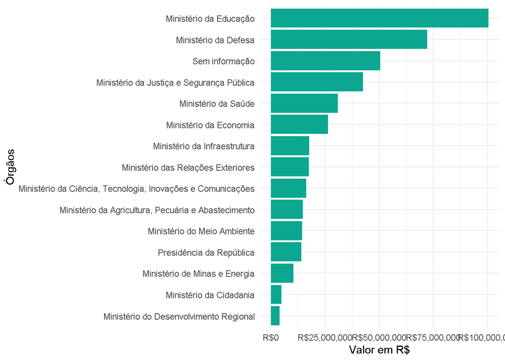

```r
# Plotando os dados com o ggplot

ggplot(p1, aes(x = reorder(orgao, valor), y = valor)) +
  geom_bar(stat = "identity", fill = "#0ba791") +
  coord_flip() +
  scale_y_continuous(labels = scales::dollar_format(prefix = "R$")) +
  labs(x = "Órgãos", y = "Valor em R$") +
  theme_minimal()
```

```r
# 2 - Qual é o valor gasto por cidade?

#Criando um dataframe com as 15 cidades que gastam mais
p2 <- dados %>%
  group_by(Destinos) %>%
  summarise(n = sum(Valor.passagens)) %>%
  arrange(desc(n)) %>%
  top_n(15)
#Alterando o nome das colunas
names(p2) <- c("destino", "valor")

p2
```

| destino | valor |
| --- | --- |
| Brasília/DF | 88009638 |
| Informações protegidas por sigilo | 45675238 |
| Rio de Janeiro/RJ | 29999886 |
| São Paulo/SP | 25764054 |
| Sem informação | 21891215 |
| Manaus/AM | 8463212 |
| Recife/PE | 6833241 |
| Belo Horizonte/MG | 6691385 |
| Curitiba/PR | 6388793 |
| Belém/PA | 5982406 |

[output cut: 5 more lines]

Aqui podemos ver quais foram as 15 cidades que mais gastaram, e o valor gasto por cada uma.

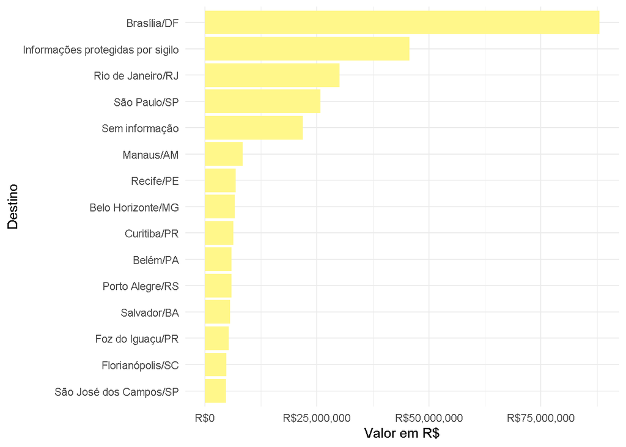

```r
#Criando o gráfico
ggplot(p2, aes(x = reorder(destino, valor), y = valor))+
  geom_bar(stat = "identity", fill = "#FFF78A")+
  coord_flip()+
  scale_y_continuous(labels = scales::dollar_format(prefix = "R$")) +
  labs(x = "Destino", y = "Valor em R$")+
  theme_minimal()
```

```r
# 3 - Qual é a quantidade de viagens por mês?

#Criando um dataframe com a quantidade de viagens por Ano/mês
p3 <- dados %>%
  group_by(data.inicio.formatada) %>%
  summarise(qtd = n_distinct(Identificador.do.processo.de.viagem))

head(p3,12)
```

| data.inicio.formatada | qtd |
| --- | --- |
| 2019-01 | 30626 |
| 2019-02 | 55399 |
| 2019-03 | 64242 |
| 2019-04 | 69559 |
| 2019-05 | 78039 |
| 2019-06 | 70971 |
| 2019-07 | 63009 |
| 2019-08 | 74432 |
| 2019-09 | 60535 |
| 2019-10 | 60021 |

[output cut: 2 more lines]

Aqui podemos ver a quantidade total de viagens realizadas por mês.

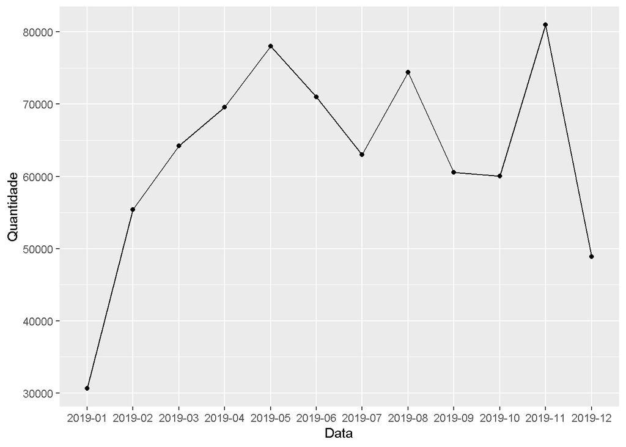

```r
#Criando o gráfico
ggplot(p3, aes(x = data.inicio.formatada, y = qtd, group = 1)) +
  geom_line() +
  geom_point() +
  labs(x = "Data", y = "Quantidade")
```

```r
install.packages("rmarkdown")
install.packages('tinytex')
library(tinytex)
```